# Developing Data Products: Course Project

author: Hedley Stirrat date: 7 June 2020 autosize: true

Financial independence/early retirement calculator

# What is FI/RE?

Financial independence/early retirement is a goal for many people. However, there are a lot of factors that could contribute to or detract from the accumulation of wealth for financial independence.

For example, if you saved an extra $5000 per year, how much sooner would you be financially independent?

Of course, it’s not easy to visualise the end goal when your retirement could be twenty or thirty years away. And that’s where this Shiny app comes in handy: You can use it to project the time it would take for you to reach financial independence, and modify some of the contributing factors to see how you could reach that goal earlier!

# How it works

You’ll be asked to provide a few simple inputs. For example, what annual income are you targeting from your investments once you’ve retired? How much are you intending to contribute toward your retirement accounts per year?

The app takes these inputs and calculates your predicted retirement year, how close to financial independence you are, and what that path looks like.

Then, you can play around with the numbers, and see what you can do to get there earlier!

# What’s going on behind the scenes?

The financial independence/early retirement predictor is based on this simple function that calculates compounding interest from your investment accounts:

```r
# function to calculate number of years until retirement
cmpd_interest_until_target <- function(rate, initial, target, injection) {
    dat <- data.frame(year = 0, principal = initial)
    while(dat[nrow(dat), 'principal'] < target) {
        this_year <- dat[nrow(dat), 'year'] + 1
        this_principal <- dat[nrow(dat), 'principal'] + rate * dat[nrow(dat), 'principal'] + injection
        dat <- bind_rows(dat, data.frame(year = this_year, principal = this_principal))
    }
    return (dat)
}
```

# What does it look like?

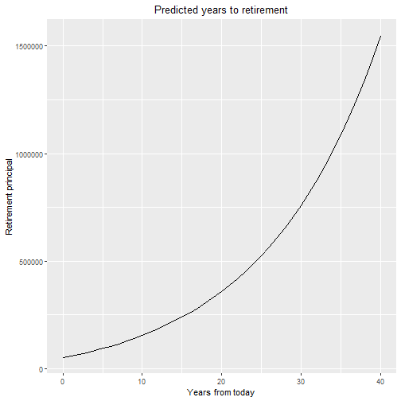